# Psychometric Evaluation of the PHQ-9 in U.S. Adults Using NHANES 2017–March 2020

Reliability, Dimensionality, Functional Difficulty, and Clinical Interpretation

Author

Shane Hodson

Published

July 22, 2026

# 1 Project status

This report documents the completed Stage 1 data audit, Stage 2A weighted descriptive analyses, and Stage 2B reliability and item analysis.

Stage 1 includes:

- source-file, linkage and response-code audits;
- sample-definition and missingness checks;
- evaluation of the `DPQ100` routing pattern;
- validation of the required NHANES survey-design variables.

Stage 2A includes:

- construction and validation of the NHANES survey-design object;
- weighted PHQ-9 item-response proportions;
- weighted PHQ-9 total-score descriptives;
- weighted symptom-severity band estimates;
- weighted `DPQ100` descriptives among routed respondents;
- an extended functional-difficulty distribution retaining structural skips and missing responses as separate categories;
- exported descriptive tables and figures.

Stage 2B includes:

- assessment of item floor effects and response-category sparsity;
- corrected item-total correlations;
- estimation and validation of the polychoric correlation matrix;
- ordinal coefficient alpha;
- McDonald’s omega total;
- reliability estimates after removing individual items;
- nonparametric bootstrap confidence intervals based on 2,000 participant-level resamples;
- exported reliability tables and figures.

Factor analysis, confirmatory modelling, measurement invariance, functional-difficulty regression modelling, diagnostic interpretation and substantive clinical interpretation have not begun.

Stage 2B reliability estimates are interpreted as evidence about internal consistency in the complete-PHQ-9 analytic sample. They are not treated as evidence of validity or unidimensionality.

# 2 Dataset

The project uses the combined NHANES 2017–March 2020 pre-pandemic release.

The primary files are:

- `P_DPQ.xpt`: Mental Health—Depression Screener
- `P_DEMO.xpt`: demographic and survey-design variables

The files are linked using the NHANES respondent identifier `SEQN`.

Raw NHANES files are downloaded programmatically and are not redistributed through the repository.

# 3 Stage 1: Data audit

## 3.1 Source-file audit

Initial NHANES source-file audit

| file | rows | columns | unique_seqn | duplicate_seqn |
| --- | --- | --- | --- | --- |
| P_DPQ.xpt | 8965 | 11 | 8965 | 0 |
| P_DEMO.xpt | 15560 | 29 | 15560 | 0 |

## 3.2 SEQN linkage audit

Linkage audit using SEQN

| check | n |
| --- | --- |
| Rows in P_DPQ | 8965 |
| Unique SEQN in P_DPQ | 8965 |
| Duplicated SEQN in P_DPQ | 0 |
| Rows in P_DEMO | 15560 |
| Unique SEQN in P_DEMO | 15560 |
| Duplicated SEQN in P_DEMO | 0 |
| P_DPQ records not found in P_DEMO | 0 |
| P_DEMO adults not found in P_DPQ | 728 |

All 8,965 depression-screener records were successfully matched to the demographic file.

Adults appearing in the demographic file but not in the depression-screener file are retained in the sample-flow documentation but are not added to the depression analysis sample.

## 3.3 PHQ-9 variable dictionary

PHQ-9 and functional-difficulty variable dictionary

| Variable | Item number | Symptom content | Role | Included in PHQ-9 total |
| --- | --- | --- | --- | --- |
| DPQ010 | 1 | Little interest or pleasure | PHQ-9 symptom item | Yes |
| DPQ020 | 2 | Depressed mood or hopelessness | PHQ-9 symptom item | Yes |
| DPQ030 | 3 | Sleep disturbance | PHQ-9 symptom item | Yes |
| DPQ040 | 4 | Tiredness or low energy | PHQ-9 symptom item | Yes |
| DPQ050 | 5 | Appetite disturbance | PHQ-9 symptom item | Yes |
| DPQ060 | 6 | Negative self-evaluation | PHQ-9 symptom item | Yes |
| DPQ070 | 7 | Concentration difficulties | PHQ-9 symptom item | Yes |
| DPQ080 | 8 | Psychomotor slowing or agitation | PHQ-9 symptom item | Yes |
| DPQ090 | 9 | Thoughts of death or self-harm | PHQ-9 symptom item | Yes |
| DPQ100 | NA | Functional difficulty | External functional-difficulty item | No |

## 3.4 Response-code audit

Observed questionnaire response codes

| variable | response_status | raw_value | n | percent |
| --- | --- | --- | --- | --- |
| DPQ010 | Don’t know | 9 | 6 | 0.07 |
| DPQ010 | Refused | 7 | 4 | 0.04 |
| DPQ010 | System missing | NA | 657 | 7.33 |
| DPQ010 | Valid response: 0 | 0 | 6166 | 68.78 |
| DPQ010 | Valid response: 1 | 1 | 1372 | 15.30 |
| DPQ010 | Valid response: 2 | 2 | 450 | 5.02 |
| DPQ010 | Valid response: 3 | 3 | 310 | 3.46 |
| DPQ020 | Don’t know | 9 | 5 | 0.06 |
| DPQ020 | Refused | 7 | 2 | 0.02 |
| DPQ020 | System missing | NA | 659 | 7.35 |
| DPQ020 | Valid response: 0 | 0 | 6187 | 69.01 |
| DPQ020 | Valid response: 1 | 1 | 1456 | 16.24 |
| DPQ020 | Valid response: 2 | 2 | 387 | 4.32 |
| DPQ020 | Valid response: 3 | 3 | 269 | 3.00 |
| DPQ030 | Don’t know | 9 | 5 | 0.06 |
| DPQ030 | Refused | 7 | 3 | 0.03 |
| DPQ030 | System missing | NA | 659 | 7.35 |
| DPQ030 | Valid response: 0 | 0 | 5023 | 56.03 |
| DPQ030 | Valid response: 1 | 1 | 1890 | 21.08 |
| DPQ030 | Valid response: 2 | 2 | 621 | 6.93 |
| DPQ030 | Valid response: 3 | 3 | 764 | 8.52 |
| DPQ040 | Don’t know | 9 | 4 | 0.04 |
| DPQ040 | Refused | 7 | 4 | 0.04 |
| DPQ040 | System missing | NA | 660 | 7.36 |
| DPQ040 | Valid response: 0 | 0 | 4164 | 46.45 |
| DPQ040 | Valid response: 1 | 1 | 2682 | 29.92 |
| DPQ040 | Valid response: 2 | 2 | 754 | 8.41 |
| DPQ040 | Valid response: 3 | 3 | 697 | 7.77 |
| DPQ050 | Don’t know | 9 | 4 | 0.04 |
| DPQ050 | Refused | 7 | 2 | 0.02 |
| DPQ050 | System missing | NA | 660 | 7.36 |
| DPQ050 | Valid response: 0 | 0 | 6165 | 68.77 |
| DPQ050 | Valid response: 1 | 1 | 1293 | 14.42 |
| DPQ050 | Valid response: 2 | 2 | 464 | 5.18 |
| DPQ050 | Valid response: 3 | 3 | 377 | 4.21 |
| DPQ060 | Don’t know | 9 | 6 | 0.07 |
| DPQ060 | Refused | 7 | 3 | 0.03 |
| DPQ060 | System missing | NA | 661 | 7.37 |
| DPQ060 | Valid response: 0 | 0 | 6881 | 76.75 |
| DPQ060 | Valid response: 1 | 1 | 968 | 10.80 |
| DPQ060 | Valid response: 2 | 2 | 239 | 2.67 |
| DPQ060 | Valid response: 3 | 3 | 207 | 2.31 |
| DPQ070 | Don’t know | 9 | 3 | 0.03 |
| DPQ070 | Refused | 7 | 2 | 0.02 |
| DPQ070 | System missing | NA | 661 | 7.37 |
| DPQ070 | Valid response: 0 | 0 | 6862 | 76.54 |
| DPQ070 | Valid response: 1 | 1 | 892 | 9.95 |
| DPQ070 | Valid response: 2 | 2 | 254 | 2.83 |
| DPQ070 | Valid response: 3 | 3 | 291 | 3.25 |
| DPQ080 | Don’t know | 9 | 5 | 0.06 |
| DPQ080 | Refused | 7 | 2 | 0.02 |
| DPQ080 | System missing | NA | 661 | 7.37 |
| DPQ080 | Valid response: 0 | 0 | 7422 | 82.79 |
| DPQ080 | Valid response: 1 | 1 | 531 | 5.92 |
| DPQ080 | Valid response: 2 | 2 | 196 | 2.19 |
| DPQ080 | Valid response: 3 | 3 | 148 | 1.65 |
| DPQ090 | Don’t know | 9 | 4 | 0.04 |
| DPQ090 | Refused | 7 | 2 | 0.02 |
| DPQ090 | System missing | NA | 663 | 7.40 |
| DPQ090 | Valid response: 0 | 0 | 7976 | 88.97 |
| DPQ090 | Valid response: 1 | 1 | 233 | 2.60 |
| DPQ090 | Valid response: 2 | 2 | 51 | 0.57 |
| DPQ090 | Valid response: 3 | 3 | 36 | 0.40 |
| DPQ100 | Don’t know | 9 | 4 | 0.04 |
| DPQ100 | Refused | 7 | 1 | 0.01 |
| DPQ100 | System missing | NA | 3425 | 38.20 |
| DPQ100 | Valid response: 0 | 0 | 4074 | 45.44 |
| DPQ100 | Valid response: 1 | 1 | 1181 | 13.17 |
| DPQ100 | Valid response: 2 | 2 | 209 | 2.33 |
| DPQ100 | Valid response: 3 | 3 | 71 | 0.79 |

The audit distinguishes valid responses from refusal, “don’t know” and system-missing values.

No unexpected questionnaire response codes were identified.

## 3.5 Missingness audit

Item-level missingness audit

| variable | total_n | valid_0_to_3 | refused_code_7 | dont_know_code_9 | system_missing | unexpected_code | valid_percent | unavailable_percent |
| --- | --- | --- | --- | --- | --- | --- | --- | --- |
| DPQ010 | 8965 | 8298 | 4 | 6 | 657 | 0 | 92.56 | 7.44 |
| DPQ020 | 8965 | 8299 | 2 | 5 | 659 | 0 | 92.57 | 7.43 |
| DPQ030 | 8965 | 8298 | 3 | 5 | 659 | 0 | 92.56 | 7.44 |
| DPQ040 | 8965 | 8297 | 4 | 4 | 660 | 0 | 92.55 | 7.45 |
| DPQ050 | 8965 | 8299 | 2 | 4 | 660 | 0 | 92.57 | 7.43 |
| DPQ060 | 8965 | 8295 | 3 | 6 | 661 | 0 | 92.53 | 7.47 |
| DPQ070 | 8965 | 8299 | 2 | 3 | 661 | 0 | 92.57 | 7.43 |
| DPQ080 | 8965 | 8297 | 2 | 5 | 661 | 0 | 92.55 | 7.45 |
| DPQ090 | 8965 | 8296 | 2 | 4 | 663 | 0 | 92.54 | 7.46 |
| DPQ100 | 8965 | 5535 | 1 | 4 | 3425 | 0 | 61.74 | 38.26 |

## 3.6 DPQ100 routing audit

DPQ100 status by PHQ-9 response pattern

| phq_response_pattern | dpq100_status | n | row_percent |
| --- | --- | --- | --- |
| All nine PHQ-9 items equal 0 | DPQ100 system missing | 2754 | 100.00 |
| At least one PHQ-9 item above 0 | DPQ100 don’t know | 3 | 0.05 |
| At least one PHQ-9 item above 0 | DPQ100 refused | 1 | 0.02 |
| At least one PHQ-9 item above 0 | DPQ100 system missing | 1 | 0.02 |
| At least one PHQ-9 item above 0 | Valid DPQ100 response | 5517 | 99.91 |
| Incomplete PHQ-9 | DPQ100 don’t know | 1 | 0.15 |
| Incomplete PHQ-9 | DPQ100 system missing | 670 | 97.24 |
| Incomplete PHQ-9 | Valid DPQ100 response | 18 | 2.61 |

All participants with valid zero responses to all nine PHQ-9 items had a system-missing `DPQ100` response.

Among participants endorsing at least one PHQ-9 symptom, nearly all had a valid `DPQ100` response.

This pattern is consistent with structural questionnaire routing among participants reporting no PHQ-9 symptoms.

Structurally skipped `DPQ100` responses are not recoded as “not difficult at all.”

## 3.7 Initial sample flow

Initial analytic sample flow

| stage | n |
| --- | --- |
| All records in P_DEMO | 15560 |
| Adults aged 18 or older in P_DEMO | 9693 |
| All records in P_DPQ | 8965 |
| P_DPQ records linked to P_DEMO | 8965 |
| Linked records aged 18 or older | 8965 |
| Adults with all nine PHQ-9 items valid | 8276 |
| Adults with valid DPQ100 | 5535 |
| Adults with complete PHQ-9 and valid DPQ100 | 5517 |

## 3.8 Survey-design variable audit

NHANES survey-design variable audit

| variable | description | total_n | missing_n | valid_n | distinct_values |
| --- | --- | --- | --- | --- | --- |
| WTMECPRP | Combined 2017-March 2020 MEC examination weight | 8965 | 0 | 8965 | 8366 |
| SDMVPSU | Masked variance primary sampling unit | 8965 | 0 | 8965 | 3 |
| SDMVSTRA | Masked variance stratum | 8965 | 0 | 8965 | 24 |

The combined-cycle examination weight, masked variance stratum and masked variance primary sampling unit variables were present for all 8,965 linked depression-screener records.

## 3.9 Cleaned questionnaire-code check

Questionnaire values after recoding non-substantive responses

| variable | minimum | maximum | missing_n | unexpected_after_cleaning |
| --- | --- | --- | --- | --- |
| DPQ010 | 0 | 3 | 667 | 0 |
| DPQ020 | 0 | 3 | 666 | 0 |
| DPQ030 | 0 | 3 | 667 | 0 |
| DPQ040 | 0 | 3 | 668 | 0 |
| DPQ050 | 0 | 3 | 666 | 0 |
| DPQ060 | 0 | 3 | 670 | 0 |
| DPQ070 | 0 | 3 | 666 | 0 |
| DPQ080 | 0 | 3 | 668 | 0 |
| DPQ090 | 0 | 3 | 669 | 0 |
| DPQ100 | 0 | 3 | 3430 | 0 |

Refusal, “don’t know” and system-missing responses were treated as missing values.

After cleaning, each PHQ-9 symptom item contained only valid values from 0 to 3 or missing values.

# 4 Stage 2A: Weighted descriptive analyses

## 4.1 Analytic samples

The linked depression-screener dataset contains 8,965 adults.

The analysis-specific samples are:

- **8,276 participants** with valid responses to all nine PHQ-9 items;
- **5,522 participants** with complete PHQ-9 data and at least one endorsed symptom;
- **5,517 participants** with complete PHQ-9 data, at least one endorsed symptom and valid `DPQ100`;
- **2,754 participants** with zero on all nine PHQ-9 items and structurally skipped `DPQ100`;
- **5 participants** with complete PHQ-9 data, at least one endorsed symptom and missing `DPQ100`.

The complete-PHQ-9 sample is used for total-score and symptom-severity descriptives.

Item-response estimates use all available valid responses for each individual item.

The primary `DPQ100` distribution is restricted to routed respondents with valid responses.

## 4.2 Survey design

The survey-design object was created from the full linked depression-screener dataset using:

- examination weight: `WTMECPRP`;
- masked variance stratum: `SDMVSTRA`;
- masked variance primary sampling unit: `SDMVPSU`;
- nested PSU identifiers within strata.

The design contains 49 nested PSUs across 24 strata.

No observed stratum contained fewer than two PSUs.

Analysis-specific samples were defined as survey domains after the full survey-design object had been created.

Weighted means and item-response proportions were estimated using `svymean()`. Item-response confidence intervals were calculated from the design-based standard errors.

Weighted variances were estimated using `svyvar()`.

Proportions for individual total scores, severity bands and `DPQ100` categories were estimated using `svyciprop()` with logit-transformed 95% confidence intervals.

## 4.3 Weighted PHQ-9 item-response proportions

Item-specific valid sample sizes ranged from 8,295 to 8,299.

The weighted response proportions sum to 100% within rounding error for each item.

Weighted PHQ-9 item-response proportions. Item-specific estimates use all available valid responses.

| Item | Symptom content | Response | Unweighted n | Weighted estimate (95% CI) |
| --- | --- | --- | --- | --- |
| DPQ010 | Little interest or pleasure | Not at all | 6166 | 76.07% (75.02–77.11%) |
| DPQ010 | Little interest or pleasure | Several days | 1372 | 16.09% (15.09–17.09%) |
| DPQ010 | Little interest or pleasure | More than half the days | 450 | 4.56% (3.89–5.23%) |
| DPQ010 | Little interest or pleasure | Nearly every day | 310 | 3.29% (2.69–3.88%) |
| DPQ020 | Depressed mood or hopelessness | Not at all | 6187 | 75.69% (74.23–77.16%) |
| DPQ020 | Depressed mood or hopelessness | Several days | 1456 | 18.00% (16.50–19.50%) |
| DPQ020 | Depressed mood or hopelessness | More than half the days | 387 | 3.69% (3.25–4.14%) |
| DPQ020 | Depressed mood or hopelessness | Nearly every day | 269 | 2.61% (2.23–3.00%) |
| DPQ030 | Sleep disturbance | Not at all | 5023 | 59.55% (58.07–61.03%) |
| DPQ030 | Sleep disturbance | Several days | 1890 | 24.14% (22.74–25.53%) |
| DPQ030 | Sleep disturbance | More than half the days | 621 | 8.21% (7.31–9.10%) |
| DPQ030 | Sleep disturbance | Nearly every day | 764 | 8.10% (7.25–8.96%) |
| DPQ040 | Tiredness or low energy | Not at all | 4164 | 48.52% (46.45–50.60%) |
| DPQ040 | Tiredness or low energy | Several days | 2682 | 33.89% (31.40–36.38%) |
| DPQ040 | Tiredness or low energy | More than half the days | 754 | 9.24% (8.36–10.13%) |
| DPQ040 | Tiredness or low energy | Nearly every day | 697 | 8.34% (7.34–9.34%) |
| DPQ050 | Appetite disturbance | Not at all | 6165 | 75.33% (73.54–77.11%) |
| DPQ050 | Appetite disturbance | Several days | 1293 | 15.86% (14.42–17.30%) |
| DPQ050 | Appetite disturbance | More than half the days | 464 | 4.64% (3.77–5.51%) |
| DPQ050 | Appetite disturbance | Nearly every day | 377 | 4.17% (3.44–4.90%) |
| DPQ060 | Negative self-evaluation | Not at all | 6881 | 82.58% (81.48–83.69%) |
| DPQ060 | Negative self-evaluation | Several days | 968 | 12.70% (11.70–13.70%) |
| DPQ060 | Negative self-evaluation | More than half the days | 239 | 2.37% (1.96–2.77%) |
| DPQ060 | Negative self-evaluation | Nearly every day | 207 | 2.35% (2.06–2.65%) |
| DPQ070 | Concentration difficulties | Not at all | 6862 | 82.66% (81.13–84.19%) |
| DPQ070 | Concentration difficulties | Several days | 892 | 11.23% (10.07–12.39%) |
| DPQ070 | Concentration difficulties | More than half the days | 254 | 2.92% (2.29–3.55%) |
| DPQ070 | Concentration difficulties | Nearly every day | 291 | 3.18% (2.54–3.82%) |
| DPQ080 | Psychomotor slowing or agitation | Not at all | 7422 | 90.17% (88.96–91.38%) |
| DPQ080 | Psychomotor slowing or agitation | Several days | 531 | 6.21% (5.21–7.21%) |
| DPQ080 | Psychomotor slowing or agitation | More than half the days | 196 | 1.97% (1.64–2.29%) |
| DPQ080 | Psychomotor slowing or agitation | Nearly every day | 148 | 1.65% (1.12–2.18%) |
| DPQ090 | Thoughts of death or self-harm | Not at all | 7976 | 96.70% (96.31–97.10%) |
| DPQ090 | Thoughts of death or self-harm | Several days | 233 | 2.43% (2.04–2.83%) |
| DPQ090 | Thoughts of death or self-harm | More than half the days | 51 | 0.52% (0.38–0.65%) |
| DPQ090 | Thoughts of death or self-harm | Nearly every day | 36 | 0.35% (0.17–0.52%) |

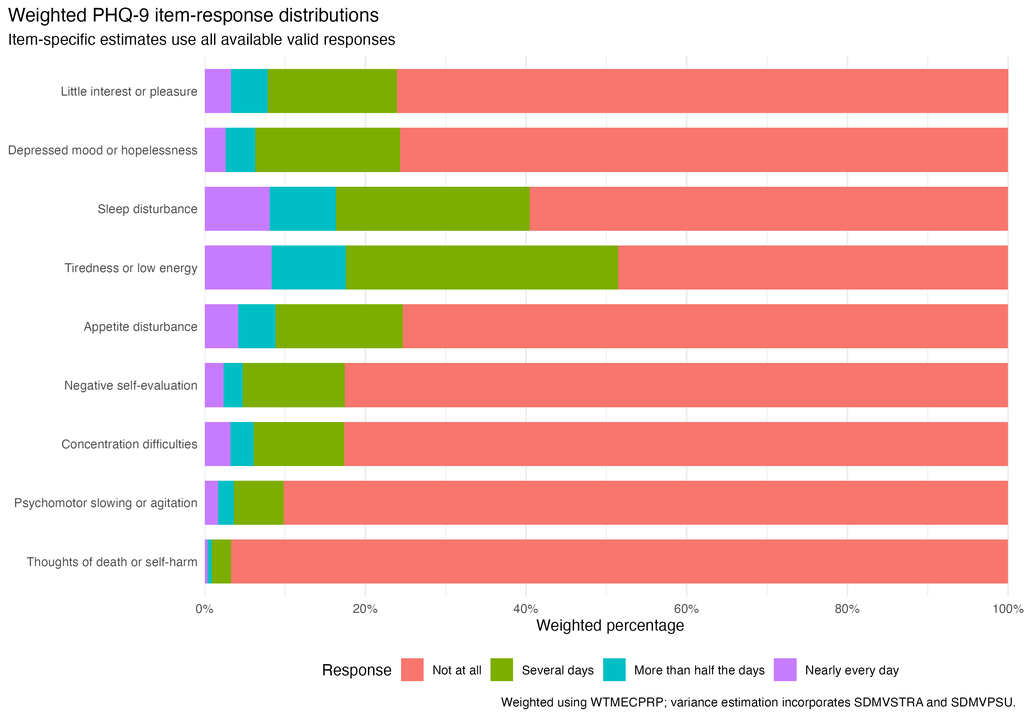

## 4.4 Weighted PHQ-9 total-score distribution

The complete-PHQ-9 sample contains 8,276 participants.

Observed PHQ-9 total scores range from 0 to 27.

Weighted PHQ-9 total-score summary.

| Measure | Estimate |
| --- | --- |
| Unweighted sample size | 8,276 |
| Weighted mean | 3.18 |
| Standard error of weighted mean | 0.06 |
| 95% confidence interval for weighted mean | 3.06–3.31 |
| Weighted standard deviation | 4.09 |
| Observed minimum | 0 |
| Observed maximum | 27 |

The weighted mean PHQ-9 total score was 3.18, with a 95% confidence interval from 3.06 to 3.31.

The weighted standard deviation was 4.09.

Weighted distribution of PHQ-9 total scores in the complete-PHQ-9 sample.

| PHQ-9 total | Unweighted n | Weighted estimate (95% CI) |
| --- | --- | --- |
| 0 | 2754 | 32.36% (30.35–34.44%) |
| 1 | 1101 | 14.38% (13.31–15.53%) |
| 2 | 955 | 12.15% (10.97–13.43%) |
| 3 | 734 | 9.13% (7.94–10.49%) |
| 4 | 565 | 6.90% (6.05–7.87%) |
| 5 | 409 | 5.09% (4.31–5.99%) |
| 6 | 326 | 3.89% (3.47–4.35%) |
| 7 | 252 | 2.53% (2.03–3.16%) |
| 8 | 232 | 2.78% (2.24–3.45%) |
| 9 | 181 | 2.25% (1.76–2.88%) |
| 10 | 154 | 2.06% (1.66–2.56%) |
| 11 | 123 | 1.24% (0.92–1.67%) |
| 12 | 93 | 1.06% (0.73–1.54%) |
| 13 | 63 | 0.63% (0.45–0.88%) |
| 14 | 69 | 0.96% (0.68–1.37%) |
| 15 | 50 | 0.47% (0.29–0.74%) |
| 16 | 43 | 0.48% (0.32–0.70%) |
| 17 | 37 | 0.37% (0.22–0.60%) |
| 18 | 41 | 0.35% (0.22–0.54%) |
| 19 | 19 | 0.16% (0.07–0.36%) |
| 20 | 19 | 0.22% (0.11–0.43%) |
| 21 | 17 | 0.18% (0.11–0.30%) |
| 22 | 15 | 0.14% (0.08–0.27%) |
| 23 | 12 | 0.11% (0.06–0.23%) |
| 24 | 5 | 0.04% (0.01–0.10%) |
| 25 | 3 | 0.03% (0.01–0.14%) |
| 26 | 3 | 0.05% (0.01–0.19%) |
| 27 | 1 | 0.01% (0.00–0.07%) |

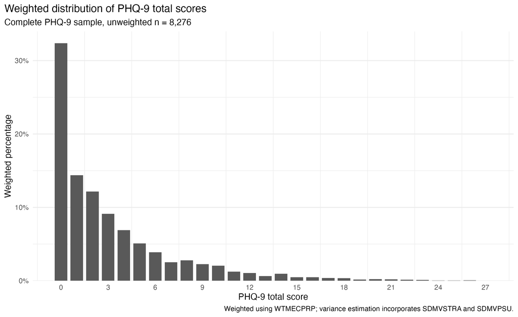

## 4.5 Weighted symptom-severity bands

The conventional score bands used in this descriptive analysis are:

- minimal: 0–4;
- mild: 5–9;
- moderate: 10–14;
- moderately severe: 15–19;
- severe: 20–27.

These categories describe score ranges and are not treated as psychiatric diagnoses.

Weighted PHQ-9 symptom-severity bands in the complete-PHQ-9 sample.

| Severity band | Unweighted n | Weighted estimate (95% CI) |
| --- | --- | --- |
| Minimal (0–4) | 6109 | 74.92% (73.49–76.30%) |
| Mild (5–9) | 1400 | 16.54% (15.14–18.04%) |
| Moderate (10–14) | 502 | 5.95% (5.10–6.94%) |
| Moderately severe (15–19) | 190 | 1.81% (1.50–2.19%) |
| Severe (20–27) | 75 | 0.78% (0.60–1.01%) |

The weighted distribution was 74.92% minimal, 16.54% mild, 5.95% moderate, 1.81% moderately severe and 0.78% severe.

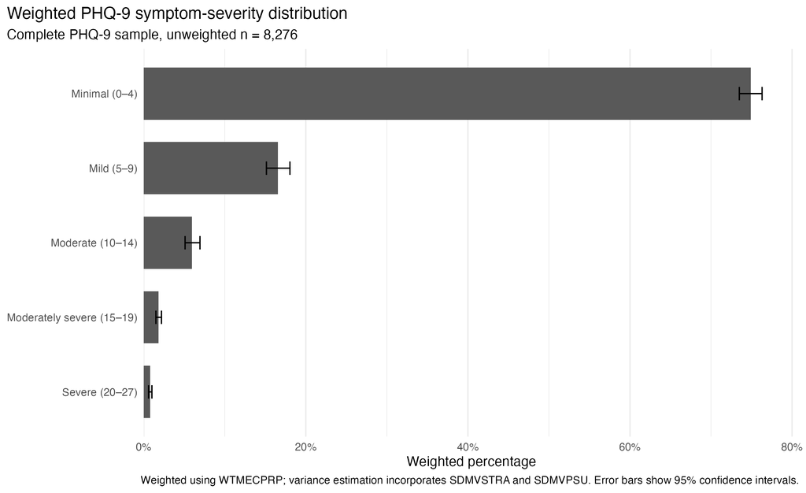

## 4.6 DPQ100 among routed respondents

The primary functional-difficulty descriptive sample contains 5,517 participants who:

- had complete PHQ-9 data;
- endorsed at least one PHQ-9 symptom;
- provided a valid `DPQ100` response.

This section reports the weighted response distribution only.

It does not model the relationship between PHQ-9 scores and functional difficulty.

Weighted DPQ100 distribution among routed respondents with valid functional-difficulty data.

| Response | Unweighted n | Weighted estimate (95% CI) |
| --- | --- | --- |
| Not difficult at all | 4060 | 74.64% (72.73–76.46%) |
| Somewhat difficult | 1177 | 20.79% (19.07–22.61%) |
| Very difficult | 209 | 3.40% (2.51–4.60%) |
| Extremely difficult | 71 | 1.17% (0.81–1.68%) |

Among routed respondents, 74.64% reported “not difficult at all,” 20.79% reported “somewhat difficult,” 3.40% reported “very difficult,” and 1.17% reported “extremely difficult.”

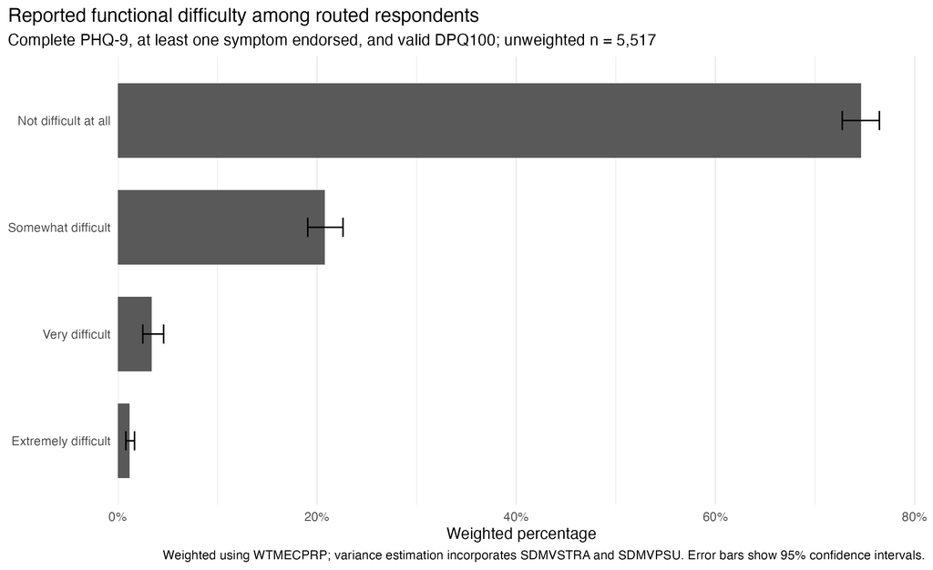

## 4.7 Extended functional-difficulty categories

The extended table uses the complete-PHQ-9 sample of 8,276 participants.

Participants with zero on all nine PHQ-9 items are retained in a separate category:

> No PHQ-9 symptoms / DPQ100 structurally skipped

The five symptom-positive participants without a valid `DPQ100` response are also shown separately.

Neither group is assigned to an observed functional-difficulty response category.

Extended weighted functional-difficulty distribution in the complete-PHQ-9 sample.

| Category | Unweighted n | Weighted estimate (95% CI) |
| --- | --- | --- |
| No PHQ-9 symptoms / DPQ100 structurally skipped | 2754 | 32.36% (30.35–34.44%) |
| Not difficult at all | 4060 | 50.47% (48.30–52.64%) |
| Somewhat difficult | 1177 | 14.05% (12.91–15.28%) |
| Very difficult | 209 | 2.30% (1.70–3.11%) |
| Extremely difficult | 71 | 0.79% (0.55–1.14%) |
| Symptom-positive / DPQ100 missing | 5 | 0.03% (0.01–0.06%) |

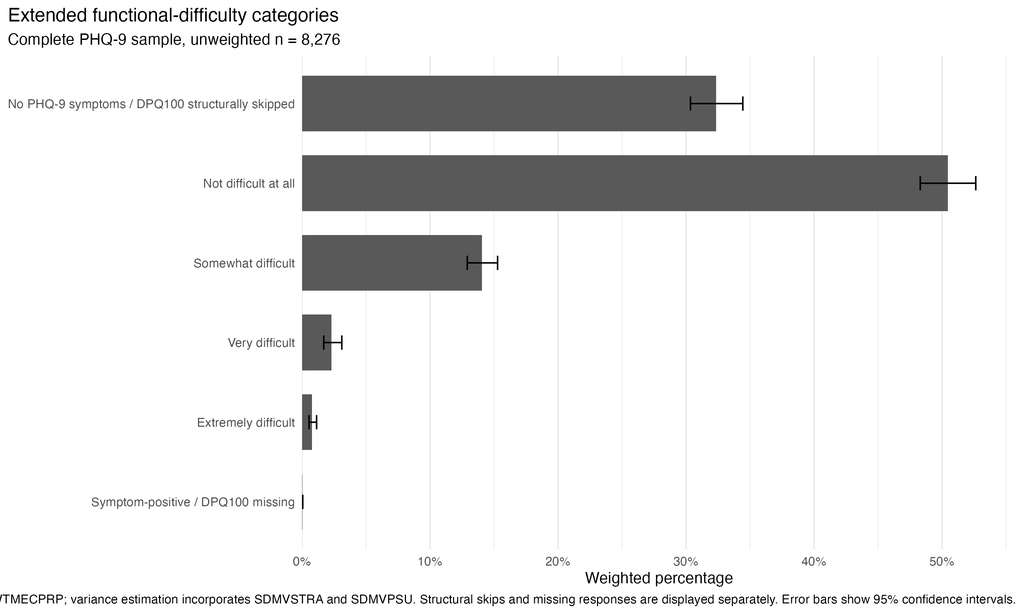

# 5 Stage 2A validation checks

The following checks were completed:

- the linked depression-screener sample contains 8,965 records;
- the complete-PHQ-9 sample contains 8,276 records;
- the symptom-positive complete-PHQ-9 sample contains 5,522 records;
- the routed valid-`DPQ100` sample contains 5,517 records;
- the structural-skip group contains 2,754 records;
- the weighted response proportions sum to 100% within rounding error for each PHQ-9 item;
- the score-distribution counts sum to 8,276;
- the weighted score-distribution proportions sum to 100% within rounding error;
- the severity-band counts sum to 8,276;
- the weighted severity-band proportions sum to 100% within rounding error;
- the routed `DPQ100` counts sum to 5,517;
- the weighted routed-`DPQ100` proportions sum to 100% within rounding error;
- the extended functional-difficulty counts sum to 8,276;
- the weighted extended-category proportions sum to 100% within rounding error;
- no symptom-free participant had a valid `DPQ100` response;
- five symptom-positive participants had missing `DPQ100` responses and remain classified as missing.

The completed survey-design object is saved locally as:

```
data/processed/nhanes_design_stage2a.rds
```

The Stage 2A working dataset is saved locally as:

```
data/processed/phq9_stage2a_data.rds
```

These processed files are excluded from version control.

# 6 Stage 2B: Reliability and item analysis

## 6.1 Analytic sample

Stage 2B used the complete-PHQ-9 analytic sample of 8,276 participants.

All nine PHQ-9 items had valid scores from 0 to 3 for every participant in this sample. No item-level missing values were present in the Stage 2B item matrix.

The reliability analyses were sample-based psychometric analyses. Survey weights, strata and primary sampling units were not incorporated into the reliability coefficients. The resulting estimates therefore describe internal consistency in the complete-PHQ-9 analytic sample rather than nationally representative reliability parameters.

## 6.2 Methods

### 6.2.1 Item floor effects and response-category sparsity

For each PHQ-9 item, the unweighted frequency and percentage of responses in categories 0, 1, 2 and 3 were calculated.

The percentage responding 0 was used to describe the item floor effect. The percentage responding 3 was also reported.

Response categories containing fewer than 1% of valid responses were flagged as sparse. This threshold was used as a descriptive screening rule only. It was not used as an automatic basis for collapsing response categories or removing an item.

### 6.2.2 Corrected item-total correlations

Corrected item-total correlations were calculated as Pearson correlations between each PHQ-9 item and the sum of the remaining eight items.

The focal item was excluded from its comparison score to avoid part–whole inflation.

Two-sided 95% confidence intervals were calculated using Fisher’s $z$ transformation, as implemented by `cor.test()` for Pearson correlations. The manually calculated estimates were validated against the `r.drop` output from `psych::alpha()`.

### 6.2.3 Polychoric correlations

A polychoric correlation matrix was estimated because the PHQ-9 items are ordered categorical variables with four response categories.

The matrix was estimated using `psych::polychoric()` with:

- a continuity correction of 0.5 for empty bivariate response cells;
- global thresholds;
- automatic matrix smoothing disabled.

The raw matrix was checked for:

- finite values;
- symmetry;
- unit diagonal values;
- positive definiteness.

Matrix smoothing would have been applied only if the raw matrix was not positive definite. The raw matrix was positive definite and did not require smoothing.

The polychoric correlations are reported as item-association estimates. They are not interpreted as evidence that the PHQ-9 is unidimensional.

### 6.2.4 Ordinal coefficient alpha

Ordinal coefficient alpha was calculated from the polychoric correlation matrix.

For $k$ items and mean inter-item polychoric correlation $\bar{r}$, ordinal alpha was calculated as:

$$\alpha =
\frac{k\bar{r}}
{1 + (k - 1)\bar{r}}$$

The result was validated against the standardised alpha returned by `psych::alpha()` when applied to the same polychoric matrix.

Ordinal alpha was also recalculated after removing each item individually. These item-removal estimates were treated as diagnostic information rather than automatic item-deletion criteria.

### 6.2.5 McDonald’s omega total

McDonald’s omega total was estimated from a single-factor congeneric reliability model fitted to the polychoric correlation matrix using minimum-residual extraction.

The one-factor model was used only to obtain the uniqueness estimates required for omega total. Factor loadings, model fit and alternative dimensional structures were not evaluated during Stage 2B.

For the unit-weighted total score, omega total was calculated as:

$$\omega_t =
1 -
\frac{\sum_i \theta_i}
{\mathrm{Var}(X)}$$

where $\theta_i$ denotes the estimated uniqueness of item $i$, and $\mathrm{Var}(X)$ is the observed variance of the standardised unit-weighted total score, calculated as the sum of all elements in the polychoric correlation matrix.

Omega total was also recalculated after removing each item individually. These estimates were treated as diagnostic information and not as automatic item-deletion criteria.

### 6.2.6 Bootstrap uncertainty intervals

Uncertainty intervals for ordinal alpha and omega total were estimated using 2,000 ordinary nonparametric participant-level bootstrap resamples.

For each resample:

1. participants were sampled with replacement;
2. the polychoric correlation matrix was re-estimated;
3. positive definiteness was checked;
4. ordinal alpha was recalculated;
5. omega total was recalculated.

The reported 95% confidence intervals are percentile bootstrap intervals.

These are participant-level bootstrap intervals for the complete analytic sample. They are not survey-design-based confidence intervals and should not be interpreted as nationally representative reliability intervals.

## 6.3 Results

### 6.3.1 Item floor effects and response-category sparsity

PHQ-9 item floor effects and response-category sparsity in the complete-PHQ-9 analytic sample.

| Item | Symptom content | Response 0 (%) | Response 3 (%) | Smallest category (%) | Empty categories | Categories below 1% |
| --- | --- | --- | --- | --- | --- | --- |
| DPQ010 | Little interest or pleasure | 74.36 | 3.71 | 3.71 | 0 | None |
| DPQ020 | Depressed mood or hopelessness | 74.57 | 3.20 | 3.20 | 0 | None |
| DPQ030 | Sleep disturbance | 60.57 | 9.21 | 7.46 | 0 | None |
| DPQ040 | Tiredness or low energy | 50.19 | 8.41 | 8.41 | 0 | None |
| DPQ050 | Appetite disturbance | 74.30 | 4.53 | 4.53 | 0 | None |
| DPQ060 | Negative self-evaluation | 82.94 | 2.48 | 2.48 | 0 | None |
| DPQ070 | Concentration difficulties | 82.72 | 3.48 | 3.03 | 0 | None |
| DPQ080 | Psychomotor slowing or agitation | 89.49 | 1.76 | 1.76 | 0 | None |
| DPQ090 | Thoughts of death or self-harm | 96.15 | 0.42 | 0.42 | 0 | 2, 3 |

No PHQ-9 item had an empty response category.

The percentage responding 0 ranged from 50.19% for tiredness or low energy (`DPQ040`) to 96.15% for thoughts of death or self-harm (`DPQ090`).

`DPQ090` had the strongest floor effect. Its response categories 2 and 3 each contained fewer than 1% of participants. No response category for any other item fell below the predefined 1% screening threshold.

The sparse upper categories for `DPQ090` were retained. They were not collapsed, and the item was not removed.

### 6.3.2 Corrected item-total correlations

Corrected PHQ-9 item-total correlations. Each item was correlated with the sum of the remaining eight items.

| Item | Symptom content | Corrected item-total r | 95% CI |
| --- | --- | --- | --- |
| DPQ010 | Little interest or pleasure | 0.574 | 0.559–0.588 |
| DPQ020 | Depressed mood or hopelessness | 0.682 | 0.670–0.693 |
| DPQ030 | Sleep disturbance | 0.555 | 0.540–0.570 |
| DPQ040 | Tiredness or low energy | 0.612 | 0.598–0.625 |
| DPQ050 | Appetite disturbance | 0.541 | 0.525–0.556 |
| DPQ060 | Negative self-evaluation | 0.596 | 0.582–0.610 |
| DPQ070 | Concentration difficulties | 0.540 | 0.525–0.555 |
| DPQ080 | Psychomotor slowing or agitation | 0.480 | 0.464–0.497 |
| DPQ090 | Thoughts of death or self-harm | 0.394 | 0.376–0.412 |

All nine corrected item-total correlations were positive.

The correlations ranged from 0.394 for `DPQ090` to 0.682 for depressed mood or hopelessness (`DPQ020`).

The lower correlation for `DPQ090` is considered alongside its strong floor effect and sparse upper response categories. It is not treated as sufficient evidence for deleting the item.

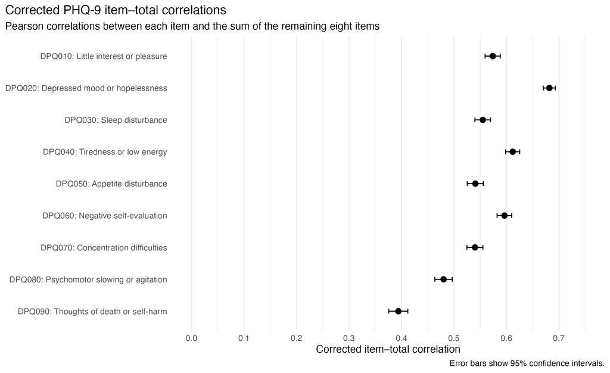

### 6.3.3 Polychoric correlation matrix

Polychoric correlation matrix for the nine PHQ-9 items in the complete-PHQ-9 analytic sample.

| Item | DPQ010 | DPQ020 | DPQ030 | DPQ040 | DPQ050 | DPQ060 | DPQ070 | DPQ080 | DPQ090 |
| --- | --- | --- | --- | --- | --- | --- | --- | --- | --- |
| DPQ010 | 1.000 | 0.708 | 0.509 | 0.595 | 0.528 | 0.608 | 0.546 | 0.521 | 0.531 |
| DPQ020 | 0.708 | 1.000 | 0.558 | 0.610 | 0.561 | 0.769 | 0.623 | 0.608 | 0.724 |
| DPQ030 | 0.509 | 0.558 | 1.000 | 0.629 | 0.528 | 0.509 | 0.521 | 0.503 | 0.469 |
| DPQ040 | 0.595 | 0.610 | 0.629 | 1.000 | 0.581 | 0.552 | 0.545 | 0.518 | 0.499 |
| DPQ050 | 0.528 | 0.561 | 0.528 | 0.581 | 1.000 | 0.541 | 0.525 | 0.529 | 0.464 |
| DPQ060 | 0.608 | 0.769 | 0.509 | 0.552 | 0.541 | 1.000 | 0.601 | 0.581 | 0.724 |
| DPQ070 | 0.546 | 0.623 | 0.521 | 0.545 | 0.525 | 0.601 | 1.000 | 0.601 | 0.523 |
| DPQ080 | 0.521 | 0.608 | 0.503 | 0.518 | 0.529 | 0.581 | 0.601 | 1.000 | 0.568 |
| DPQ090 | 0.531 | 0.724 | 0.469 | 0.499 | 0.464 | 0.724 | 0.523 | 0.568 | 1.000 |

The polychoric matrix was finite, symmetric and positive definite. Its minimum eigenvalue was 0.204, and no smoothing was required.

All off-diagonal correlations were positive. They ranged from 0.464 to 0.769, with a mean off-diagonal correlation of 0.570.

The strongest estimated association was between depressed mood or hopelessness (`DPQ020`) and negative self-evaluation (`DPQ060`), $r = .769$.

The weakest estimated association was between appetite disturbance (`DPQ050`) and thoughts of death or self-harm (`DPQ090`), $r = .464$.

These correlations describe relationships among the ordered item responses. Their magnitude is not treated as proof that a one-factor model is adequate.

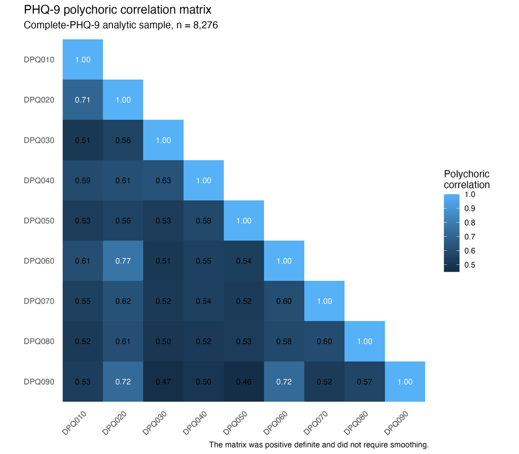

### 6.3.4 Ordinal alpha and omega total

Ordinal internal-consistency estimates with 95% nonparametric percentile bootstrap intervals.

| Coefficient | Estimate | Bootstrap standard error | 95% bootstrap CI | Successful resamples |
| --- | --- | --- | --- | --- |
| Ordinal coefficient alpha | 0.923 | 0.0022 | 0.918–0.927 | 2,000 |
| McDonald’s omega total | 0.923 | 0.0021 | 0.919–0.927 | 2,000 |

Ordinal coefficient alpha was 0.923, with a 95% percentile bootstrap confidence interval from 0.918 to 0.927.

McDonald’s omega total was 0.923, with a 95% percentile bootstrap confidence interval from 0.919 to 0.927.

All nine estimated uniqueness values used in the omega-total calculation were finite, non-negative and no greater than 1. They ranged from 0.236 to 0.525.

Because omega total was estimated from a one-factor congeneric model, its interpretation will be revisited after the Stage 3 dimensionality analysis.

The bootstrap means were close to the point estimates, and estimated bootstrap bias was negligible.

Ordinal alpha and omega total were high in the complete analytic sample. They provide evidence about internal consistency but do not establish that the PHQ-9 is valid, diagnostically accurate or adequately represented by one dimension.

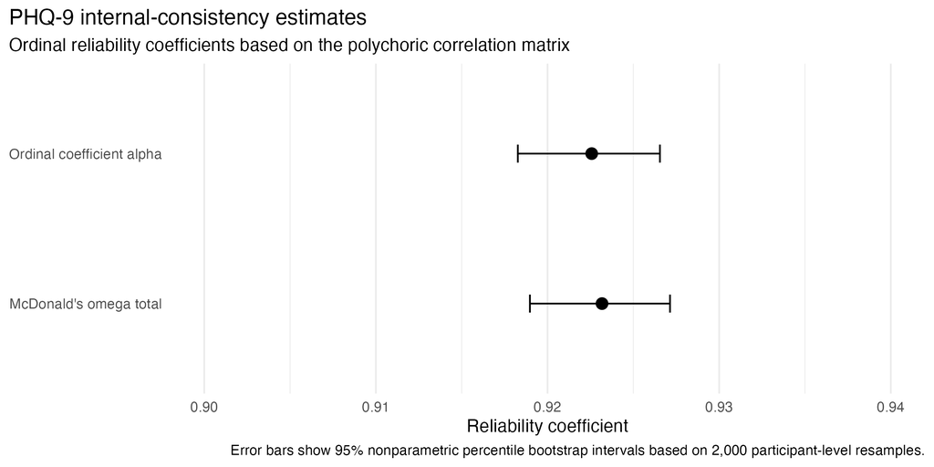

### 6.3.5 Reliability if an item was removed

Ordinal alpha and omega total after removing each PHQ-9 item individually.

| Item | Symptom content | Ordinal alpha if removed | Change in alpha | Omega total if removed | Change in omega |
| --- | --- | --- | --- | --- | --- |
| DPQ010 | Little interest or pleasure | 0.914 | -0.0087 | 0.915 | -0.0086 |
| DPQ020 | Depressed mood or hopelessness | 0.907 | -0.0160 | 0.907 | -0.0164 |
| DPQ030 | Sleep disturbance | 0.917 | -0.0051 | 0.918 | -0.0049 |
| DPQ040 | Tiredness or low energy | 0.914 | -0.0085 | 0.915 | -0.0081 |
| DPQ050 | Appetite disturbance | 0.917 | -0.0054 | 0.918 | -0.0052 |
| DPQ060 | Negative self-evaluation | 0.910 | -0.0127 | 0.910 | -0.0128 |
| DPQ070 | Concentration difficulties | 0.915 | -0.0080 | 0.915 | -0.0078 |
| DPQ080 | Psychomotor slowing or agitation | 0.915 | -0.0074 | 0.916 | -0.0071 |
| DPQ090 | Thoughts of death or self-harm | 0.914 | -0.0082 | 0.915 | -0.0083 |

Removing any individual item lowered both ordinal alpha and omega total.

The largest decreases occurred when `DPQ020` was removed. Ordinal alpha decreased by 0.0160 and omega total decreased by 0.0164.

The item-removal results do not support improving internal consistency by deleting any single PHQ-9 item. They are not interpreted as evidence that every item is interchangeable or that item content should be judged only by its contribution to a reliability coefficient.

### 6.3.6 Bootstrap diagnostics

Stage 2B reliability-bootstrap diagnostics.

| Measure | Result |
| --- | --- |
| Requested bootstrap resamples | 2,000 |
| Successful bootstrap resamples | 2,000 |
| Failed bootstrap resamples | 0 |
| Resampled matrices requiring smoothing | 0 |
| Resamples producing computational warnings | 0 |
| Minimum raw matrix eigenvalue across resamples | 0.171 |
| Elapsed computation time | 4.56 minutes |

All 2,000 bootstrap resamples completed successfully.

No resampled polychoric matrix required smoothing, and no resample produced a computational warning. The minimum raw eigenvalue observed across the resampled matrices was 0.171.

# 7 Stage 2B validation checks

The following checks were completed:

- the Stage 2B complete-PHQ-9 sample contains 8,276 participants;
- the Stage 2B item matrix contains nine items;
- all item values fall within the valid range from 0 to 3;
- the Stage 2B item matrix contains no missing values;
- each item-response distribution sums to 8,276 participants;
- each item-response distribution sums to 100% within numerical tolerance;
- no PHQ-9 item has an empty response category;
- only `DPQ090` has response categories below the 1% screening threshold;
- manually calculated corrected item-total correlations match `psych::alpha()` `r.drop` values within numerical precision;
- the maximum item-total validation difference was approximately `6.13e-14`;
- the raw polychoric matrix is finite, symmetric and positive definite;
- the raw polychoric matrix has a minimum eigenvalue of 0.204;
- the polychoric matrix did not require smoothing;
- the manually calculated ordinal alpha matches the standardised alpha from `psych::alpha()` exactly;
- the two algebraically equivalent omega-total calculations agree within approximately `1.11e-16`;
- all nine uniqueness estimates used for omega total were finite, non-negative and no greater than 1, with values ranging from 0.236 to 0.525;
- removing any individual item lowers both ordinal alpha and omega total;
- all 2,000 final bootstrap resamples completed successfully;
- no final bootstrap replicate required matrix smoothing;
- no final bootstrap replicate produced a computational warning.

The final bootstrap object is saved locally as:

```
data/processed/phq9_reliability_bootstrap_stage2b.rds
```

This processed object is excluded from version control.

# 8 Analyses not included in Stage 2B

Stage 2B is limited to reliability and item analysis.

The following analyses remain outside the present stage:

- exploratory factor analysis;
- confirmatory factor analysis;
- evaluation of one-factor model fit;
- comparison of alternative factor structures;
- measurement-invariance testing;
- survey-weighted latent-variable modelling;
- functional-difficulty regression modelling;
- diagnostic-accuracy analysis;
- diagnostic interpretation;
- treatment-need claims;
- substantive clinical interpretation.

A single-factor congeneric model was used only to obtain the uniqueness estimates required for omega total. Its factor loadings and model fit were not interpreted as evidence about the dimensional structure of the PHQ-9.

The Stage 2B findings provide evidence about internal consistency and item relationships in the complete-PHQ-9 analytic sample. They do not establish validity, unidimensionality, diagnostic accuracy, psychiatric diagnosis or treatment need.